# Final Project

Desiree Smith

12/2/2021

# R Reference Guide

## Loading Data and Packages

```r
require(here)
require(palmerpenguins)
library(palmerpenguins)

ginkgo = read.csv(here("data", "ginkgo_data_2021.csv"))
```

## Data Structures

### c()

```r
# Create a vector of numbers:
num_vec  = c(1, 4, 8, 9, 13)
```

### length()

- Helps to determine and set the length of vectors and factors

```r
length(ginkgo$max_width)
```

```
## [1] 756
```

### matrix()

- Helps to create a 2D data structure using your data. It can be created from vectors.

```r
matrix(ginkgo$max_width, byrow= 3, ncol= 6)
```

```
##         [,1] [,2] [,3] [,4]  [,5] [,6]
##   [1,]  71.0   64   55   62  65.0   70
##   [2,]  63.0   56   51   57  59.0   63
##   [3,]  70.0   50   56   46  54.0   62
##   [4,]  56.0   55   59   60  63.0   61
##   [5,]  58.0   55   53   81  94.0   75
##   [6,]  82.0   86   79   93  88.0   76
##   [7,]  71.0   91   71   82  65.0   83
##   [8,]  73.0  102   78   88  81.0   70
##   [9,]  80.0   96   80   82  86.0   87
##  [10,]  89.0   69   93   98  81.0   79
##  [11,]  82.0   85   81   59  53.0   83
##  [12,]  80.0   77   81   76  82.0   81
##  [13,]  77.0   68   41   70  68.0   80
##  [14,]  89.0   90   71   64  55.0   62
```

[output cut: 112 more lines]

### data.frame()

- Data frame is a way of storing data in R and how to structure it.They have the same number of rows.

```r
ginkgo_df= data.frame(ginkgo$max_width, ginkgo$max_depth)
ginkgo_df
```

```
##     ginkgo.max_width ginkgo.max_depth
## 1               71.0               40
## 2               64.0               38
## 3               55.0               32
## 4               62.0               40
## 5               65.0               40
## 6               70.0               50
## 7               63.0               42
## 8               56.0               35
## 9               51.0               45
## 10              57.0               37
## 11              59.0               41
## 12              63.0               42
## 13              70.0               50
## 14              50.0               46
```

[output cut: 742 more lines]

- **nrow** is used to return the number of rows of the specified matrix and **ncol** is used to return the number of columns.

```r
nrow(ginkgo_df)
```

```
## [1] 756
```

```r
ncol(ginkgo_df)
```

```
## [1] 2
```

- dim is used to return/sets the dimension of the matrix. It shows the amount of rows and columns

```r
dim(ginkgo_df)
```

```
## [1] 756   2
```

## Subsetting

- Is a way to select variable and observations.You can use subset to specify the rows and columns you want to select in the data frame. You can subset by position and data frame as well.

```r
#subsetting by name
ginkgo$max_width
```

```
##   [1]  71.0  64.0  55.0  62.0  65.0  70.0  63.0  56.0  51.0  57.0  59.0  63.0
##  [13]  70.0  50.0  56.0  46.0  54.0  62.0  56.0  55.0  59.0  60.0  63.0  61.0
##  [25]  58.0  55.0  53.0  81.0  94.0  75.0  82.0  86.0  79.0  93.0  88.0  76.0
##  [37]  71.0  91.0  71.0  82.0  65.0  83.0  73.0 102.0  78.0  88.0  81.0  70.0
##  [49]  80.0  96.0  80.0  82.0  86.0  87.0  89.0  69.0  93.0  98.0  81.0  79.0
##  [61]  82.0  85.0  81.0  59.0  53.0  83.0  80.0  77.0  81.0  76.0  82.0  81.0
##  [73]  77.0  68.0  41.0  70.0  68.0  80.0  89.0  90.0  71.0  64.0  55.0  62.0
##  [85]  65.0  70.0  63.0  56.0  51.0  57.0  59.0  63.0  70.0  50.0  56.0  46.0
##  [97]  54.0  62.0  56.0  55.0  59.0  60.0  63.0  61.0  58.0  55.0  53.0  77.0
## [109]  72.0  57.0  75.0  75.0  75.0  67.0  74.0  71.0  72.0  55.0  77.0  97.0
## [121]  73.0  64.0  69.0  92.0  64.0  68.0  53.0  97.0 100.0  90.0  89.0  59.0
## [133]  97.0  76.0  85.0  90.0  87.0  85.0  80.0  86.0  89.0  84.0  88.0  80.0
## [145] 102.0  94.0  95.0 109.0  84.0  68.0  59.0  74.0  70.0  71.0  69.0  74.0
## [157]  70.0  78.0  87.0  69.0  60.0  72.0  59.0  75.0  81.0  82.0  74.0  72.0
## [169]  79.0  84.0  75.0  72.0  88.0  80.0  90.0  58.0  61.0  95.0  72.0  90.0
```

[output cut: 48 more lines]

```r
#subsetting by position.
ginkgo[1,]
```

```
##   site_id seeds_present max_width max_depth notch_depth petiole_length
## 1    7719         FALSE        71        40           0             30
```

```r
ginkgo[2,3]
```

```
## [1] 64
```

```r
ginkgo[,3]
```

```
##   [1]  71.0  64.0  55.0  62.0  65.0  70.0  63.0  56.0  51.0  57.0  59.0  63.0
##  [13]  70.0  50.0  56.0  46.0  54.0  62.0  56.0  55.0  59.0  60.0  63.0  61.0
##  [25]  58.0  55.0  53.0  81.0  94.0  75.0  82.0  86.0  79.0  93.0  88.0  76.0
##  [37]  71.0  91.0  71.0  82.0  65.0  83.0  73.0 102.0  78.0  88.0  81.0  70.0
##  [49]  80.0  96.0  80.0  82.0  86.0  87.0  89.0  69.0  93.0  98.0  81.0  79.0
##  [61]  82.0  85.0  81.0  59.0  53.0  83.0  80.0  77.0  81.0  76.0  82.0  81.0
##  [73]  77.0  68.0  41.0  70.0  68.0  80.0  89.0  90.0  71.0  64.0  55.0  62.0
##  [85]  65.0  70.0  63.0  56.0  51.0  57.0  59.0  63.0  70.0  50.0  56.0  46.0
##  [97]  54.0  62.0  56.0  55.0  59.0  60.0  63.0  61.0  58.0  55.0  53.0  77.0
## [109]  72.0  57.0  75.0  75.0  75.0  67.0  74.0  71.0  72.0  55.0  77.0  97.0
## [121]  73.0  64.0  69.0  92.0  64.0  68.0  53.0  97.0 100.0  90.0  89.0  59.0
## [133]  97.0  76.0  85.0  90.0  87.0  85.0  80.0  86.0  89.0  84.0  88.0  80.0
## [145] 102.0  94.0  95.0 109.0  84.0  68.0  59.0  74.0  70.0  71.0  69.0  74.0
## [157]  70.0  78.0  87.0  69.0  60.0  72.0  59.0  75.0  81.0  82.0  74.0  72.0
## [169]  79.0  84.0  75.0  72.0  88.0  80.0  90.0  58.0  61.0  95.0  72.0  90.0
```

[output cut: 48 more lines]

```r
subset(penguins, species == "Adelie")
```

```
## # A tibble: 152 × 8
##    species island    bill_length_mm bill_depth_mm flipper_length_mm body_mass_g
##    <fct>   <fct>              <dbl>         <dbl>             <int>       <int>
##  1 Adelie  Torgersen           39.1          18.7               181        3750
##  2 Adelie  Torgersen           39.5          17.4               186        3800
##  3 Adelie  Torgersen           40.3          18                 195        3250
##  4 Adelie  Torgersen           NA            NA                  NA          NA
##  5 Adelie  Torgersen           36.7          19.3               193        3450
##  6 Adelie  Torgersen           39.3          20.6               190        3650
##  7 Adelie  Torgersen           38.9          17.8               181        3625
##  8 Adelie  Torgersen           39.2          19.6               195        4675
##  9 Adelie  Torgersen           34.1          18.1               193        3475
## 10 Adelie  Torgersen           42            20.2               190        4250
## # … with 142 more rows, and 2 more variables: sex <fct>, year <int>
```

## Numerical Data Exploration

- The summary function helps to put together a summary of statistics of data and model.

```r
summary(ginkgo)
```

```
##     site_id      seeds_present     max_width        max_depth
##  Min.   : 1896   Mode :logical   Min.   : 16.00   Min.   : 19.00
##  1st Qu.: 3703   FALSE:636       1st Qu.: 63.00   1st Qu.: 43.00
##  Median : 6066   TRUE :120       Median : 74.00   Median : 51.00
##  Mean   : 6079                   Mean   : 74.34   Mean   : 58.51
##  3rd Qu.: 7206                   3rd Qu.: 85.00   3rd Qu.: 66.00
##  Max.   :12982                   Max.   :130.00   Max.   :145.00
##
##   notch_depth    petiole_length
##  Min.   : 0.00   Min.   :  8.00
##  1st Qu.: 0.00   1st Qu.: 34.00
##  Median : 0.00   Median : 47.00
##  Mean   : 2.99   Mean   : 48.25
##  3rd Qu.: 4.00   3rd Qu.: 60.00
##  Max.   :49.00   Max.   :113.00
##                  NA's   :4
```

```r
summary(ginkgo$max_width)
```

```
##    Min. 1st Qu.  Median    Mean 3rd Qu.    Max.
##   16.00   63.00   74.00   74.34   85.00  130.00
```

- mean () calculates the mean of the data you specifies and sd() helps to calculates the standard deviation.

```r
mean(ginkgo$max_width)
```

```
## [1] 74.33823
```

```r
sd(ginkgo$max_width)
```

```
## [1] 16.4203
```

## Graphical Data Exploration

- col = can be used to add color to your graph
- main = allows you to create a title for the graph
- xlab = and ylab = are used to label the x and y axis
- xlim = and ylim =
- pch = allows you to change the shape of your symbol in scatterplots and other graphics.
- cex = allows you to change the size of your symbol

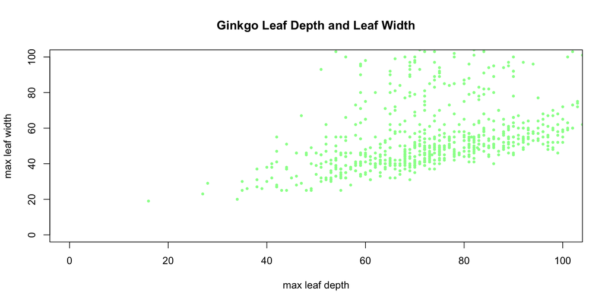

```r
ginkgo = read.csv(here("data",
                       "ginkgo_data_2021.csv"))


 plot(max_depth ~ max_width,
      data = ginkgo,
      xlim = c(0,100),
      ylim = c(0, 100),
  main = "Ginkgo Leaf Depth and Leaf Width",
  ylab = "max leaf width",
  xlab = "max leaf depth",
  col = "palegreen",
  pch = 20, cex = 0.75)
```

- breaks = is used to control the number of bars, cells or bins in a histogram

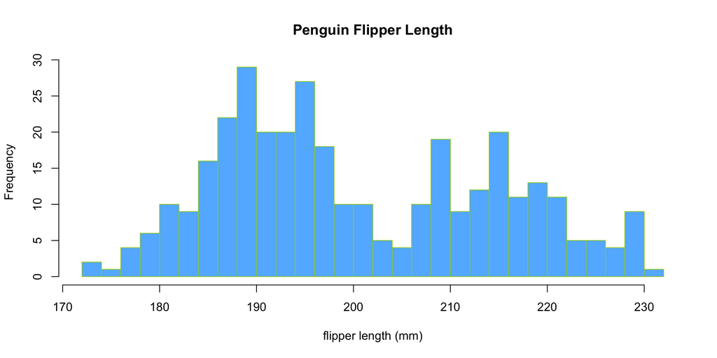

```r
hist(penguins$flipper_length_mm,
     main = "Penguin Flipper Length",
     xlab = "flipper length (mm)",
     col = "steelblue1",
     border = "yellowgreen",
     breaks = 40)
```

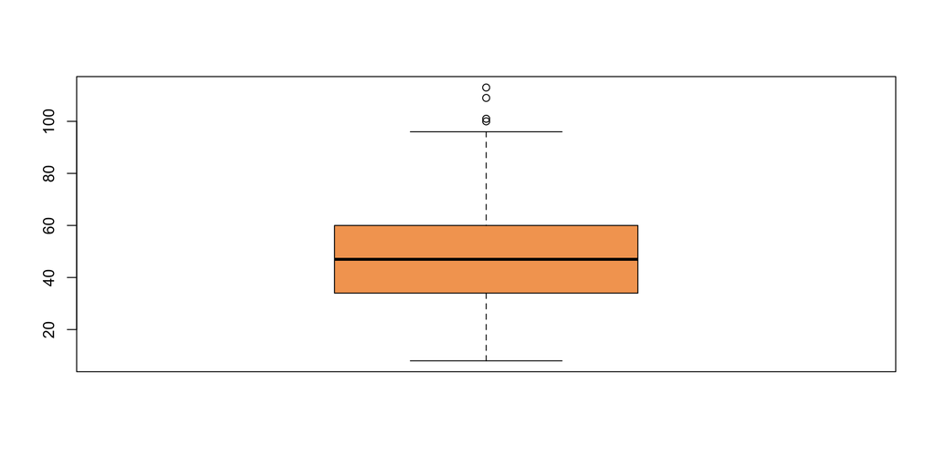

```r
boxplot(ginkgo$petiole_length, col = "sandybrown")
```

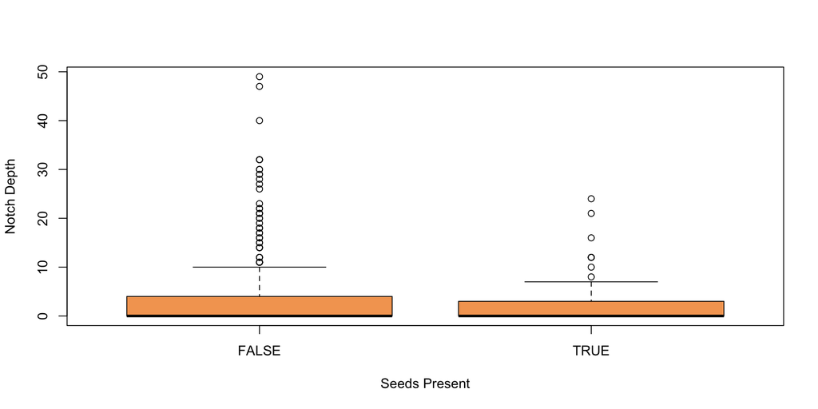

```r
boxplot(notch_depth ~ seeds_present ,
        data = ginkgo,
        ylab = "Notch Depth",
        xlab = "Seeds Present",
        col = "sandybrown")
```

- par(mfrow = c() creates a grid to to display your figures. For example, if you want two figures on the top and two at the bottom you use par(mfrow = c(2,2))

### 4-panel figure of Histogram

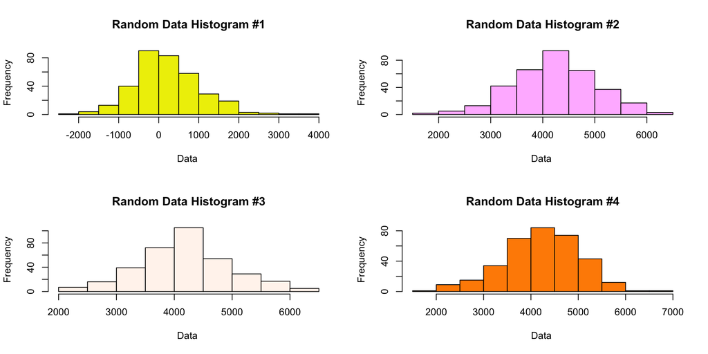

```r
dat_1 = rnorm(n = 344, mean = 202, sd = 802)
dat_2 = rnorm(n = 344, mean = 4202, sd = 802)
dat_3 = rnorm(n = 344, mean = 4202, sd = 802)
dat_4 = rnorm(n = 344, mean = 4202, sd = 802)

par(mfrow = c(2,2))

hist(dat_1,
     main = "Random Data Histogram #1",
     xlab = "Data ",
     col = "yellow2")
hist(dat_2,
     main = "Random Data Histogram #2",
     xlab = "Data ",
     col = "plum1")
hist(dat_3,
     main = "Random Data Histogram #3",
     xlab = "Data ",
     col = "seashell")
hist(dat_4,
     main = "Random Data Histogram #4",
     xlab = "Data ",
     col = "darkorange")
```

## Distribution Functions

- dnorm = density function of the normal distribution

```r
dnorm(6, mean = 10.4, sd = 2.4)
```

```
## [1] 0.03096298
```

- pnorm = distribution function

```r
pnorm(1.2, mean = 2, sd = 2)
```

```
## [1] 0.3445783
```

- qnorm = quantile function

```r
qnorm(0.85,mean=70,sd=3)
```

```
## [1] 73.1093
```

- dbinom(x, size, prob, log = FALSE)

```r
dbinom(3, 4, 0.75, log = FALSE)
```

```
## [1] 0.421875
```

- pbinom(q, size, prob, lower.tail = TRUE, log.p = FALSE)

```r
pbinom(3, 4, 0.75,lower.tail = TRUE,
       log.p = FALSE )
```

```
## [1] 0.6835937
```

- qbinom(p, size, prob, lower.tail = TRUE, log.p = FALSE)

```r
qbinom(.10, size=10, prob=.4)
```

```
## [1] 2
```

### Part 2

## Numerical Exploration

```r
delomy = read.csv(here("data","delomys.csv"))

body_mass = summary(delomy$body_mass)
body_length = summary(delomy$body_length)
shapiro.test(body_mass)
```

```
##
##  Shapiro-Wilk normality test
##
## data:  body_mass
## W = 0.9099, p-value = 0.4357
```

```r
shapiro.test(body_length)
```

```
##
##  Shapiro-Wilk normality test
##
## data:  body_length
## W = 0.80354, p-value = 0.06323
```

## Question 1

Qualitatively describe the relationship between body mass and length. Does the relationship seem linear, curved, nonexistent?

There is a clear relationship between body mass and length. The relationship is a positive relationship based on the direction it is going. It has more of a curve than a linear shape.

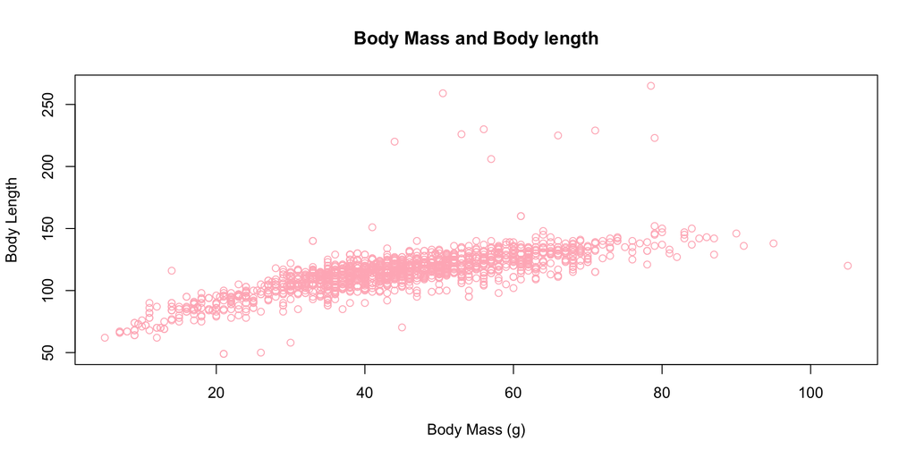

```r
plot(body_length ~ body_mass,
     data = delomy,
     main = "Body Mass and Body length",
     col = "lightpink", border = "lightgreen",
     xlab = "Body Mass (g)",
     ylab = "Body Length")
```

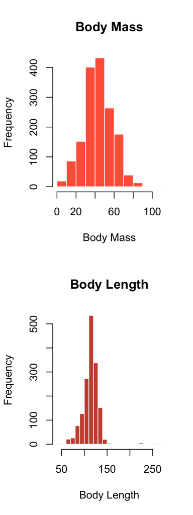

```r
par(mfrow = c(2,1))
#A histogram of body mass
hist(delomy$body_mass,
     main = "Body Mass",
     col = "tomato1", border = "ghostwhite",
     xlab = "Body Mass")

#Histogram of Body Length
hist(delomy$body_length,
     main = "Body Length",
     col = "tomato3", border = "ghostwhite",
     xlab = "Body Length",
     breaks = 17)
```

## Question 2

Qualitatively describe the shapes of the histograms. Do the data appear normally-distributed? Explain why or why not.

## Question 3

Using both the histograms and normality tests, do you think the (unconditioned) body masses and body length are normally-distributed? Contrast your visual assessment of normality to the results of the numerical normality tests.

By looking at the shapiro.test I can see that both body mass and body length seem to have large p values. This tells us that both of the models follow the normality assumption. Visually the body length histogram seems like it is not normally distributed while body mass does look normally distributed.

## Question 4

Examine the conditional boxplots. Describe any graphical evidence you see for body mass differences based on species and/or sex.

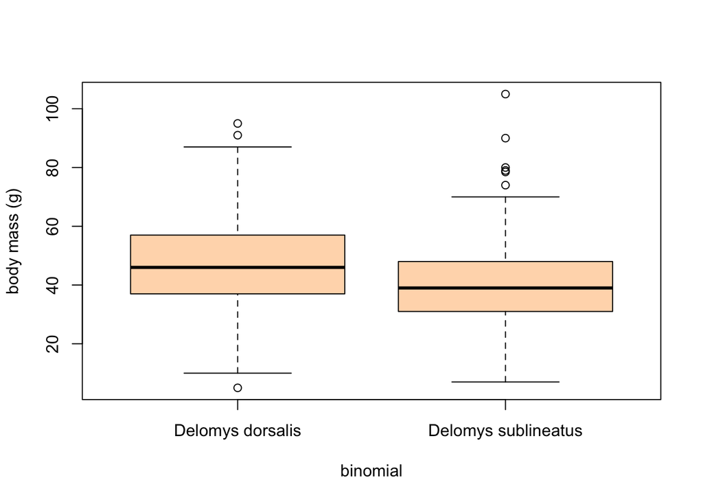

```r
#Conditional Boxplots
boxplot(body_mass ~ binomial,
    data = delomy,
    ylab = "body mass (g)",
    col= "peachpuff1")
```

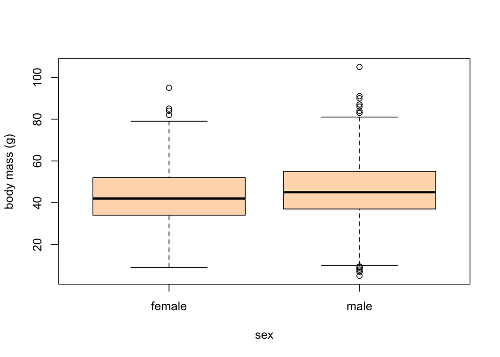

```r
boxplot(body_mass ~ sex,
    data = delomy,
    ylab = "body mass (g)",
    col= "peachpuff1")
```

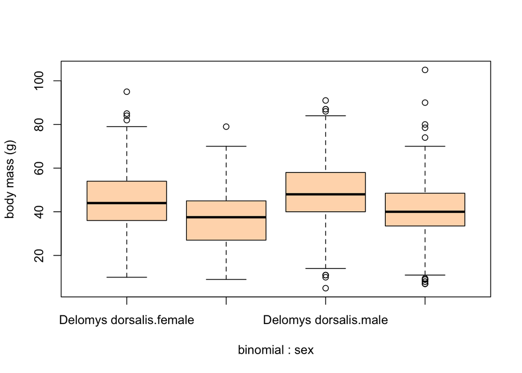

```r
boxplot(body_mass ~ binomial * sex,
    data = delomy,
    ylab = "body mass (g)",
    col= "peachpuff1")
```

## Question 5

```r
fit1 = lm(body_length ~ body_mass,
          data = delomy)

fit2 =
  lm( formula = body_mass
    ~ sex,
    data = delomy)

fit3 =
  lm(formula = body_mass ~ binomial,
    data = delomy)

fit4 = lm(
    formula = body_mass ~ sex + binomial,
    data = delomy)

fit5 = lm(
    formula = body_mass ~ sex * binomial,
    data = delomy)
```

## Question 5

```r
par(mfrow = c(2,3))
hist(fit1$residuals)
hist(fit2$residuals)
hist(fit3$residuals)
hist(fit4$residuals)
hist(fit5$residuals)

shapiro.test(fit1$residuals) #W = 0.73462,
```

```
##
##  Shapiro-Wilk normality test
##
## data:  fit1$residuals
## W = 0.73462, p-value < 2.2e-16
```

```r
#p-value < 2.2e-16
shapiro.test(fit2$residuals) #W = 0.99563,
```

```
##
##  Shapiro-Wilk normality test
##
## data:  fit2$residuals
## W = 0.99563, p-value = 0.0001541
```

```r
#p-value = 0.0001541
shapiro.test(fit3$residuals) #W = 0.99535,
```

```
##
##  Shapiro-Wilk normality test
##
## data:  fit3$residuals
## W = 0.99535, p-value = 8.103e-05
```

```r
#p-value = 8.103e-05
shapiro.test(fit4$residuals) #W = 0.99525,
```

```
##
##  Shapiro-Wilk normality test
##
## data:  fit4$residuals
## W = 0.99525, p-value = 6.805e-05
```

```r
#p-value = 6.805e-05
shapiro.test(fit5$residuals) #W = 0.99526,
```

```
##
##  Shapiro-Wilk normality test
##
## data:  fit5$residuals
## W = 0.99526, p-value = 6.816e-05
```

```r
#p-value = 6.816e-05

#The test rejects the hypothesis of normality
#when the p-value is less than or equal to 0.05.
```

[figure not shown]

What do you conclude about residual normality based on the numerical and graphical diagnostics?

Based on the numerical diagnostics, I can see that the for each of the fit models they do not follow the normality assumption. They all have low p-values this will cause us to reject the hypothesis of normality. By looking at the graphical diagnostics, it appears that the histograms look fairly normally distributed except for fit1 model.

## Question 6

Are violations of the normality assumption equally severe for all the models?

They are not equally severe for all the models. By looking at my histograms, I can see visually that the fit1 histogram seems to violate the normality assumptions the most and numerically it has the smallest p-value which confirms that we would reject the normality assumption.

## Question 7

```r
knitr::kable(coef(summary(fit1)))
```

|  | Estimate | Std. Error | t value | Pr(>\|t\|) |
| --- | --- | --- | --- | --- |
| (Intercept) | 76.1246565 | 0.9158120 | 83.12258 | 0 |
| body_mass | 0.8754988 | 0.0196905 | 44.46298 | 0 |

What is the magnitude of the mass/length relationship?

To create my coefficient I used the fit1 model and by looking at the table I can see that the magnitude of the relationship is 0.875.

## Question 8

What is the expected body length of an an animal that weighs 100g?

```r
(76.1246565 + (0.8754988 * 100))
```

```
## [1] 163.6745
```

## Question 9

What is the expected body length of an animal that weighs 0g?

```r
(76.1246565 + (0.8754988 * 0))
```

```
## [1] 76.12466
```

## Question 10

```r
coef(fit2)
```

```
## (Intercept)     sexmale
##   42.711465    2.784133
```

```r
coef(fit3)
```

```
##                 (Intercept) binomialDelomys sublineatus
##                   46.752427                   -7.683058
```

```r
coef(fit4)
```

```
##                 (Intercept)                     sexmale
##                   45.070356                    3.795395
## binomialDelomys sublineatus
##                   -8.193491
```

```r
coef(fit5)
```

```
##                         (Intercept)                             sexmale
##                         45.05545617                          3.82809084
##         binomialDelomys sublineatus sexmale:binomialDelomys sublineatus
##                         -8.14173936                         -0.09501866
```

What is the base level for sex?

Female is the base level for sex.

## Question 11

What is the base level for binomial?

Delomys dorsalis is the base level for binomial.

## Question 12

Which sex is heavier?

## Question 13

Which species is heavier?

Delomys dorsalis is the heavier species between the two.

## Question 14

```r
knitr::kable(anova(fit2)) # Pr = 0.0001951
```

|  | Df | Sum Sq | Mean Sq | F value | Pr(>F) |
| --- | --- | --- | --- | --- | --- |
| sex | 1 | 3061.678 | 3061.6779 | 13.94294 | 0.0001951 |
| Residuals | 1578 | 346507.131 | 219.5863 | NA | NA |

```r
knitr::kable(anova(fit3)) # Pr = 0
```

|  | Df | Sum Sq | Mean Sq | F value | Pr(>F) |
| --- | --- | --- | --- | --- | --- |
| binomial | 1 | 21289.68 | 21289.6805 | 102.0751 | 0 |
| Residuals | 1583 | 330164.45 | 208.5688 | NA | NA |

```r
knitr::kable(anova(fit4)) # sex Pr = 0.0001144 bin Pr = 0
```

|  | Df | Sum Sq | Mean Sq | F value | Pr(>F) |
| --- | --- | --- | --- | --- | --- |
| sex | 1 | 3061.678 | 3061.6779 | 14.95838 | 0.0001144 |
| binomial | 1 | 23727.134 | 23727.1342 | 115.92320 | 0.0000000 |
| Residuals | 1577 | 322779.997 | 204.6798 | NA | NA |

```r
knitr::kable(anova(fit5)) # sex = 0.0001150 binomial = 0 sex:binomial = 0.9504424
```

|  | Df | Sum Sq | Mean Sq | F value | Pr(>F) |
| --- | --- | --- | --- | --- | --- |
| sex | 1 | 3.061678e+03 | 3.061678e+03 | 14.948932 | 0.0001150 |
| binomial | 1 | 2.372713e+04 | 2.372713e+04 | 115.849977 | 0.0000000 |
| sex:binomial | 1 | 7.913846e-01 | 7.913846e-01 | 0.003864 | 0.9504424 |
| Residuals | 1576 | 3.227792e+05 | 2.048091e+02 | NA | NA |

Are sex and species significant predictors for body mass?

The species and sex both have an effect on the body mass of the individual.

## Question 15

Is there a significant interaction?

## Question 16

How does the significance (as measured by p-value) of either of the main effects (sex and species) differ between the single-predictor models, the additive model, and the interactive model?

I can see that the p-values vary sightly between the different models but it is not a significant difference.

## Question 17

```r
AIC(fit2) # 13006.8
```

```
## [1] 13006.8
```

```r
AIC(fit3) # 12966.36
```

```
## [1] 12966.36
```

```r
AIC(fit4) # 12896.73
```

```
## [1] 12896.73
```

```r
AIC(fit5) # 12898.72
```

```
## [1] 12898.72
```

Which two models have the lowest AIC?

Fit models 4 and 5 have the lowest AIC.

## Question 18

Which of the two models with lowest AIC scores would you select? Explain your decision based on model fit and the complexity/understanding tradeoff.